# Actividad 2: Análisis descriptivo e inferencial

Jorge Solán Morote

2025-04-25

Para la elaboración de esta actividad serán necesarias las siguientes librerías

```r
library(openxlsx)
library(ggplot2)
library(dplyr)
```

Nivel de confianza que utilizaremos a lo largo de la práctica.

```r
n_conf = 0.95
```

## 1. Breve análisis visual

Carga del archivo previa

```r
sleephealth <- read.xlsx("sleephealth_processed.xlsx")
str(sleephealth)
```

```
## 'data.frame':    374 obs. of  15 variables:
##  $ ID        : num  1 2 3 4 5 6 7 8 9 10 ...
##  $ Gender    : chr  "Male" "Male" "Male" "Male" ...
##  $ Age       : num  27 28 28 28 28 28 29 29 29 29 ...
##  $ Occupation: chr  "Software Engineer" "Doctor" "Doctor" "Sales Person" ...
##  $ SH        : num  6.1 6.2 6.2 5.9 5.9 5.9 6.3 7.8 7.8 7.8 ...
##  $ SQ        : num  6 6 6 4 4 4 6 7 7 7 ...
##  $ PHY       : num  42 60 60 30 30 30 40 75 75 75 ...
##  $ Stress    : num  6 8 8 8 8 8 7 6 6 6 ...
##  $ BMI       : chr  "Overweight" "Normal" "Normal" "Obese" ...
##  $ BP        : chr  "126/83" "125/80" "125/80" "140/90" ...
##  $ HR        : num  77 75 75 85 85 85 82 70 70 70 ...
##  $ Steps     : num  4200 10000 10000 3000 3000 3000 3500 8000 8000 8000 ...
##  $ SD        : chr  "None" "None" "None" "Sleep Apnea" ...
##  $ BPsyst    : num  126 125 125 140 140 140 140 120 120 120 ...
##  $ BPdias    : num  83 80 80 90 90 90 90 80 80 80 ...
```

Una vez cargado, se nos pide visualizar los datos a estudiar en cada pregunta planteada para hacernos una pequeña idea previa.

### 1.1 PR1

**¿La media de horas de sueño de las personas en el estudio es significativamente inferior a 7.5 horas diarias?**

Para este caso podemos ver las horas que duermen las personas en un gráfico de barras para hacernos una idea general y dónde se sitúan las 7.5 horas que querremos observar más adelante.

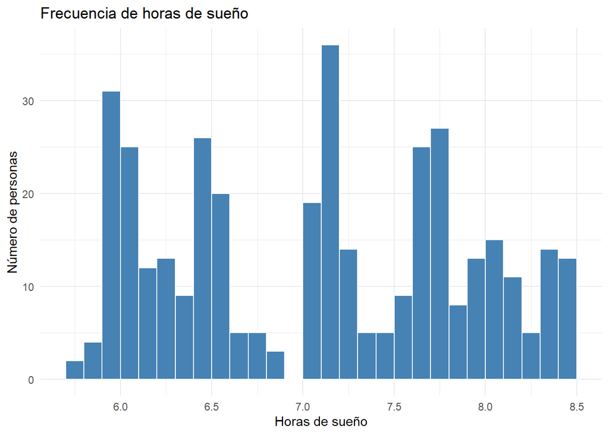

```r
library(ggplot2)

ggplot(sleephealth, aes(x = SH)) +
  geom_histogram(binwidth = 0.1, fill = "steelblue", color = "white", boundary = 0)  +
  labs(
    title = "Frecuencia de horas de sueño",
    x = "Horas de sueño",
    y = "Número de personas"
  ) +
  theme_minimal()
```

### 1.2 PR2

**¿Existen diferencias en la calidad del sueño entre géneros?**

Podemos dividir la columna de calidad de sueño en dos boxplots diferentes, uno para mujeres y otro para hombres por ver cómo lo calificaron.

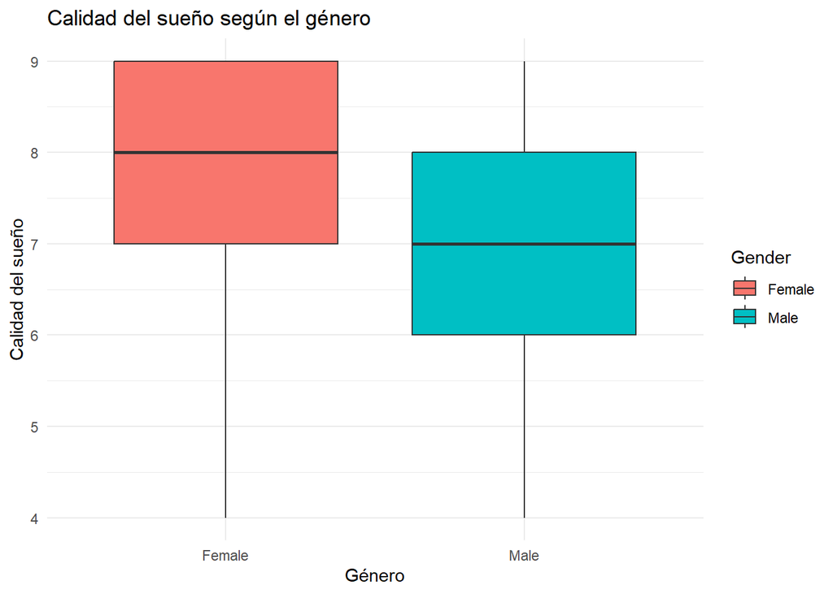

```r
library(ggplot2)

ggplot(sleephealth, aes(x = Gender, y = SQ, fill = Gender)) +
  geom_boxplot() +
  labs(title = "Calidad del sueño según el género",
       x = "Género",
       y = "Calidad del sueño") +
  theme_minimal()
```

### 1.3 PR3

**¿La proporción de personas con trastorno del sueño es mayor en las personas con niveles altos de estrés en comparación con las que presentan niveles bajos de estrés?**

Para hacer primeramente esta gráfica ponemos una nueva entrada en el dataframe por si tiene o no un trastorno del sueño.

```r
sleephealth$Disorder <- ifelse(sleephealth$SD == "None", "No", "Yes")
```

Una vez esto podemos crear una gráfica de barras apiladas desde el 0 al 100%, donde dividimos por el nivel de estrés y vemos de un vistazo rápido cómo se distribuyen, si tienen o no trastornos del sueño

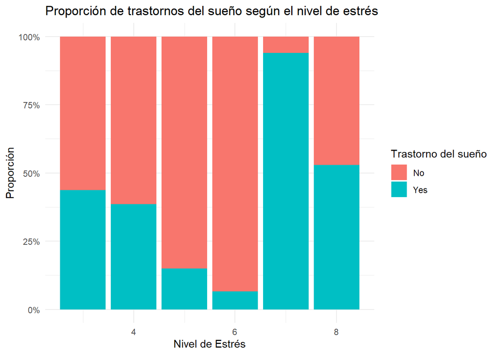

```r
ggplot(sleephealth, aes(x = Stress, fill = Disorder)) +
  geom_bar(position = "fill") +
  labs(title = "Proporción de trastornos del sueño según el nivel de estrés",
       x = "Nivel de Estrés",
       y = "Proporción",
       fill = "Trastorno del sueño") +
  scale_y_continuous(labels = scales::percent) +
  theme_minimal()
```

### 1.4 PR4

**¿Existe una relación significativa entre la categoría de BMI (body mass index) y la presencia de trastornos del sueño?**

En este caso, es igual que la anterior una gráfica de barras apiladas pero separando los trastornos de sueño y el BMI.

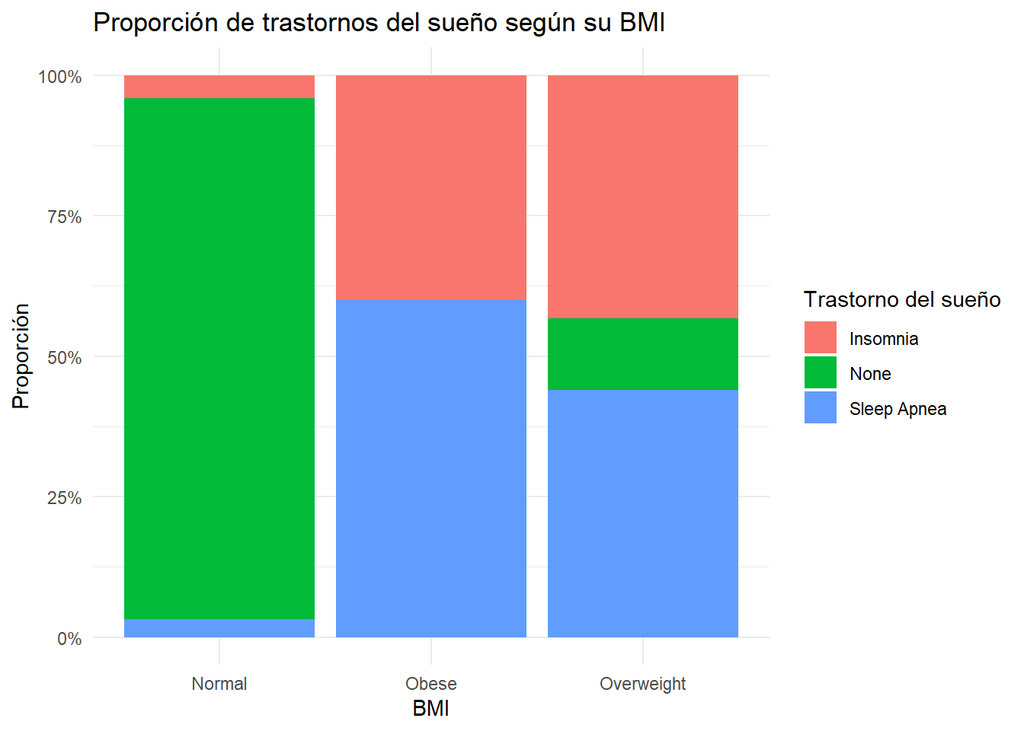

```r
ggplot(sleephealth, aes(x = BMI, fill = SD)) +
  geom_bar(position = "fill") +
  labs(title = "Proporción de trastornos del sueño según su BMI",
       x = "BMI",
       y = "Proporción",
       fill = "Trastorno del sueño") +
  scale_y_continuous(labels = scales::percent) +
  theme_minimal()
```

Una vez observados los diferentes datos, para cada pregunta se nos pide escribir sus hipótesis, explicar la elección del test que le aplicaremos y ejecutar dicho test con código propio de R, en algunos casos también desarrollar uno propio. Con las conclusiones que saquemos de los test aplicados debemos responder a la pregunta de investigación.

## 2. Media de horas de sueño (PR1)

**¿La media de horas de sueño de las personas en el estudio es significativamente inferior a 7.5 horas diarias?**

#### 2.1 Hipótesis

$H_0: \mu = 7.5$

$H_1: \mu< 7.5$

#### 2.2 Elección del test

Dado que no se conoce la varianza de la población, esta se va a estimar a partir de la muestra, por ello hemos usado la distribución t de Student para la realización de este test.

#### 2.3 Test R

Como se explica en el ejemplo 3 del apartado 2.2 de los [recursos de aprendizaj](https://materials.campus.uoc.edu/daisy/Materials/PID_00276233/pdf/PID_00276233.pdf)e, la función t.test nos ayuda a calcular el p-valor y más parámetros que nos ayudan con la resolución de qué hipótesis aceptamos

```r
t.test(sleephealth$SH, mu = 7.5, alternative = "less", conf.level = n_conf)
```

```
##
##  One Sample t-test
##
## data:  sleephealth$SH
## t = -8.9329, df = 373, p-value < 2.2e-16
## alternative hypothesis: true mean is less than 7.5
## 95 percent confidence interval:
##     -Inf 7.20024
## sample estimates:
## mean of x
##   7.13238
```

#### 2.4 Desarrollo

El estadístico de contraste para la t-Student es el siguiente a calcular:
$$t = \frac{\hat{x} - \mu_0}{\frac{s}{\sqrt{n}}}$$

```r
pr_1 <- function(mu0, conf){

  x <- sleephealth$SH
  n <- length(x)
  df = n - 1
  s <- sd(x)
  t_stat <- (mean(x) - mu0) / (s / sqrt(n))

  p_value <- pt(t_stat, df)
  # Valor crítico para prueba unilateral a la izquierda
  v_crit <- qt(1 - conf, df)
  return(c(t_stat,p_value,v_crit))
}
```

#### 2.5 Resultados

```r
result <- pr_1(7.5, n_conf)

sprintf("Valor observado = %f", result[1])
```

```
## [1] "Valor observado = -8.932869"
```

```r
sprintf("P valor = %e", result[2])
```

```
## [1] "P valor = 9.645142e-18"
```

```r
sprintf("Valor crítico = %f", result[3])
```

```
## [1] "Valor crítico = -1.648949"
```

#### 2.6 Respuesta a la pregunta

Tanto con el test desarrollado, ya que el p-valor es muy pequeño ($\alpha < 0.01$) y el estadístico de contraste es menor que el valor crítico estando en una prueba unilateral a la izquierda, como en la solución que se indica en el t.test de R, podemos rechazar la Hipótesis nula de que las media es igual a 7.5 y aceptamos que la media es menor a este valor de 7.5 horas.

## 3. Diferencias en la calidad del sueño según género (PR2)

**¿Existen diferencias en la calidad del sueño entre géneros?**

#### 3.1 Hipótesis

$H_0: \mu_1 = \mu_2$

$H_0: \mu_1 \ne \mu_2$

#### 3.2 Elección del test

Necesitamos hacer un contraste de dos muestras, hombres y mujeres para poder observar si hay o no diferencias. Ya que no sabemos las varianzas de las muestras y tenemos > 30 muestras seguimos el teorema central del límite para calcular su estadístico de contraste.

#### 3.3 Test R

Igual que en el ejercicio anterior, utilizamos la función t.test, esta vez me he fijado en el ejemplo 16 del apartado 5.2.2 donde realiza este test para 2 muestras.

```r
male_SQ <- sleephealth$SQ[sleephealth$Gender == "Male"]
female_SQ <- sleephealth$SQ[sleephealth$Gender == "Female"]

t.test(male_SQ, female_SQ, conf.level = n_conf)
```

```
##
##  Welch Two Sample t-test
##
## data:  male_SQ and female_SQ
## t = -5.8593, df = 347.96, p-value = 1.078e-08
## alternative hypothesis: true difference in means is not equal to 0
## 95 percent confidence interval:
##  -0.9304432 -0.4627786
## sample estimates:
## mean of x mean of y
##  6.968254  7.664865
```

#### 3.4 Desarrollo

El estadístico de contraste en este caso es el siguiente a calcular:

$$z = \frac{(\hat{x_1} -
\hat{x_2})}{{\sqrt{\frac{s_1^2}{n_1}+\frac{s_2^2}{n_2}}}}$$

```r
pr_2 <- function(sleephealth, conf){

  mean_m <- mean(sleephealth$SQ[sleephealth$Gender == "Male"])
  mean_f <- mean(sleephealth$SQ[sleephealth$Gender == "Female"])

  var_m <- var(sleephealth$SQ[sleephealth$Gender == "Male"])
  var_f <- var(sleephealth$SQ[sleephealth$Gender == "Female"])

  n_m <- length(sleephealth$SQ[sleephealth$Gender == "Male"])
  n_f <- length(sleephealth$SQ[sleephealth$Gender == "Female"])

  df = n_m + n_f -2

  s_x1_x2 = sqrt((var_m / n_m) +(var_f / n_f))

  z_stat = (mean_m - mean_f) / s_x1_x2
  p_value = pt(z_stat, df)
  # Valor crítico para prueba bilateral
  v_crit <- qt(1 - conf/2, df)
  return(c(z_stat,p_value,v_crit))
}
```

#### 3.5 Resultados

```r
result <- pr_2(sleephealth, n_conf)

sprintf("Valor observado = %f", result[1])
```

```
## [1] "Valor observado = -5.859318"
```

```r
sprintf("P valor = %e", result[2])
```

```
## [1] "P valor = 5.120946e-09"
```

```r
sprintf("Valor crítico = %f", result[3])
```

```
## [1] "Valor crítico = 0.062749"
```

#### 3.6 Respuesta a la pregunta

Tanto con el test desarrollado, ya que el p-valor es muy pequeño ($\alpha < 0.01$) y el estadístico de contraste es menor que el valor crítico estando en una prueba bilateral, como en la solución que se indica en el t.test de R, podemos rechazar la Hipótesis nula de que no hay diferencias entre calidades de sueño y aceptamos que sí hay diferencias.

## 4. ¿El estrés influye en los trastornos del sueño? (PR3)

**¿La proporción de personas con trastorno del sueño es mayor en las personas con niveles altos de estrés en comparación con las que presentan niveles bajos de estrés?**

#### 4.1 Hipótesis

$H_0: \mu_1 = \mu_2$

$H_1: \mu_1 \gt \mu_2$

#### 4.2 Elección del test

En esta pregunta, al igual que en la anterior trabajamos con el contraste de dos muestras, pero esta vez las muestras son proporciones, muestras dicotómicas que siguen una distribución de Bernoulli.

#### 4.3 Test R

Primero, debemos definir cuales son las personas con alto niveles de estrés y bajo niveles de estrés. Considerando que la variable “Stress” va del 1 al 10 siendo 1 niveles bajos y 10 niveles altos de estrés podemos decir, que de 7 hasta 10 se considerando nivel “alto” de estrés. Así necesitamos una nueva variable que refleje esto. Además también hacemos dicotómica si presenta o no trastornos del sueño.

```r
# Clasificación del estrés
dic_stress <- ifelse(sleephealth$Stress >= 7, 1, 0)
dic_SD <- ifelse(sleephealth$SD == "None", 0, 1)

# Personas con alto estrés y trastornos del sueño
SD_alto <- sum(dic_SD[dic_stress == 1])
total_alto <- sum(dic_stress)

# Personas con bajo estrés y trastornos del sueño
SD_bajo <- sum(dic_SD[dic_stress == 0])
total_bajo <- sum(dic_stress == 0)
```

Para este apartado me he basado en la solución que se propone en los [recursos de aprendizaje](https://materials.campus.uoc.edu/daisy/Materials/PID_00276233/pdf/PID_00276233.pdf), ejemplo 18, páginas 48 y 49, que utiliza la función de R “prop.test” para el estudio de las proporciones.

```r
prop.test(c(SD_alto, SD_bajo),
          c(total_alto, total_bajo),
          alternative = "greater")
```

```
##
##  2-sample test for equality of proportions with continuity correction
##
## data:  c(SD_alto, SD_bajo) out of c(total_alto, total_bajo)
## X-squared = 57.653, df = 1, p-value = 1.564e-14
## alternative hypothesis: greater
## 95 percent confidence interval:
##  0.3313922 1.0000000
## sample estimates:
##    prop 1    prop 2
## 0.7000000 0.2795276
```

#### 4.4 Desarrollo

El estadístico de contraste en este caso es el siguiente a calcular:

$$z = \frac{\hat{p_1} -
\hat{p_2}}{{\sqrt{p(1-p)(\frac{1}{n_1}+\frac{1}{n_2})}}}$$

```r
pr_3 <- function(dic_SD,dic_stress,conf){

  p1 <- sum(dic_SD[dic_stress == 1]) / sum(dic_stress == 1)
  p2 <- sum(dic_SD[dic_stress == 0]) / sum(dic_stress == 0)

  n1 <- sum(dic_stress == 1)
  n2 <- sum(dic_stress == 0)

  # Proporción combinada
  p <- (n1 * p1 + n2 * p2) / (n1 + n2)

  z_stat <- (p1 - p2) / sqrt(p * (1 - p) * (1/n1 + 1/n2))
  p_value <- pnorm(z_stat, lower.tail = FALSE)
  # Valor crítico para prueba unilateral a la derecha
  v_crit <- qnorm(conf)

  return(c(z_stat,p_value,v_crit))
}
```

#### 4.5 Resultados

```r
result <- pr_3(dic_SD, dic_stress,n_conf)

sprintf("Valor observado = %f", result[1])
```

```
## [1] "Valor observado = 7.705360"
```

```r
sprintf("P valor = %e", result[2])
```

```
## [1] "P valor = 6.523767e-15"
```

```r
sprintf("Valor crítico = %f", result[3])
```

```
## [1] "Valor crítico = 1.644854"
```

## 5. BMI y trastornos del sueño (PR4)

**¿Existe una relación significativa entre la categoría de BMI (body mass index) y la presencia de trastornos del sueño?**

#### 5.1 Hipótesis

- $H_0:$ No existe relación entre la categoría de BMI y la presencia de trastornos del sueño.
- $H_1:$ Existe una relación significativa entre la categoría de BMI y la presencia de trastornos del sueño.

#### 5.2 Elección del test

En este caso debemos ver la relación entre dos categorías diferentes, para este caso podemos usar el contraste Chi-Quadrado el cual se utiliza para determinar si dependencia o no entre dos variables categóricas.

#### 5.3 Test R

Para este test me he basado en los [recursos de aprendizaje](https://materials.campus.uoc.edu/daisy/Materials/PID_00276233/pdf/PID_00276233.pdf), más concretamente en el ejemplo 24 del ejercicio 13 del apartado 7 que utiliza este test.

Como se ve en el test he puesto para que simule el p_valor como en el siguiente [enlace](https://stats.stackexchange.com/questions/574075/chi-squared-approximation-may-be-incorrect).  
Esto es porque hay pocas muestras en la tabla y la aproximación puede ser correcta, utilizando esta aproximación hace varias simulaciones del p-valor para que nos dé un resultado más correcto. Si quitamos ese booleano nos aparecerá el error.

```
Aviso: Chi-squared approximation may be incorrect
```

```r
tabla_pr4 <- table(sleephealth$BMI, sleephealth$SD)
tabla_pr4
```

```
##
##              Insomnia None Sleep Apnea
##   Normal            9  200           7
##   Obese             4    0           6
##   Overweight       64   19          65
```

```r
chisq.test(tabla_pr4, simulate.p.value = TRUE)
```

```
##
##  Pearson's Chi-squared test with simulated p-value (based on 2000
##  replicates)
##
## data:  tabla_pr4
## X-squared = 245.67, df = NA, p-value = 0.0004998
```

Otro modo de hacerlo sin simular el p-valor es utilizando es calculando el test sobre la proporción con el test exacto de Fisher. Para ello, al ser proporciones debemos hacer dicotómica el trastorno de sueño como en el ejercicio anterior.

```r
tabla_pr4_2 <- table(sleephealth$BMI, dic_SD)
tabla_pr4_2
```

```
##             dic_SD
##                0   1
##   Normal     200  16
##   Obese        0  10
##   Overweight  19 129
```

```r
fisher.test(tabla_pr4_2)
```

```
##
##  Fisher's Exact Test for Count Data
##
## data:  tabla_pr4_2
## p-value < 2.2e-16
## alternative hypothesis: two.sided
```

#### 5.4 Respuesta a la pregunta

En ambas pruebas del contraste de Chi-quadrado y el test de Fisher hemos obtenido un p-valor muy pequeño, el cual nos indica que podemos rechazar la hipótesis nula de que no existe una relación entre el BMI y los trastornos del sueño y decir que sí existe esa relación.

## 6. Tabla resumen

PR1: ¿La media de horas de sueño de las personas en el estudio es significativamente inferior a 7.5  
horas diarias?  
PR2: ¿Existen diferencias en la calidad del sueño entre géneros?  
PR3: ¿La proporción de personas con trastorno del sueño es mayor en las personas con niveles altos de  
estrés en comparación con las que presentan niveles bajos de estrés?  
PR4: ¿Existe una relación significativa entre la categoría de BMI (body mass index) y la presencia de  
trastornos del sueño?

|  | PR1 | PR2 | PR3 | PR4 |
| --- | --- | --- | --- | --- |
| Hipótesis | $H_0: \mu_0 = 7.5$ $H_1: \mu_0 < 7.5$ | $H_0: \mu_1 = \mu_2$ $H_1: \mu_1 \ne \mu_2$ | $H_0: \mu_1 = \mu_2$ $H_1: \mu_1 \gt \mu_2$ | $H_0:$ No existe relación entre categorías $H_1:$ Relación entre categorías |
| Test aplicado | Una muestra. T-Student | Dos muestras | Proporciones con dos muestras | Chi-Quadrado-Fisher |
| P-valor | R: 2.2e-16 DEV: 9.645142e-18 | R: 1.078e-08 DEV: 5.120946e-09 | R: 1.564e-14 DEV: 6.523767e-15 | Chi-Q: 0.0004998 Fisher: 2.2e-16 |
| Respuesta | Rechazar $H_0$ | Rechazar $H_0$ | Rechazar $H_0$ | Rechazar $H_0$ |

## 7. Resumen ejecutivo

En esta práctica hemos tenido que corroborar o desmentir varias hipótesis, preguntas, hechas sobre un conjunto de datos.

Primeramente hemos realizado un análisis visual en diversos gráficos, con eso quizas podríamos haber respondido a si aceptábamos o no la hipótesis planteada, entendiendo la pregunta y el dataset analizado, pero además de visualmente, podemos responder a esas preguntas con lo que llamamos “contraste de hipótesis”.  
Para ello debemos definir nuestra hipótesis nula y la hipótesis alternativa de la pregunta inicial para después saber cómo tratar los datos, ya que a lo largo de la práctica hemos utilizado test diferentes a cada una de las hipótesis. El funcionamiento en todas es parecido, una vez sabemos qué test aplicar necesitamos encontrar su “estadístico de contraste” o valor observado, el cual se calcula de manera diferente para cada test.

Una vez calculado dicho valor podemos usarlo de dos maneras, o para calcular el llamado “p-valor” el cual es la probabilidad del resultado del estadístico de contraste observado o de uno más alejado cuando la hipótesis nula es cierta, así, cuando este valor es muy pequeño, podemos decir menor que 0.01 por ejemplo, debemos rechazar la hipótesis nula.

Además del “p-valor” podemos calcular el valor crítico, que depende del nivel de confianza que hayamos establecido antes(por ejemplo, 95%). Este valor crítico actúa como un límite, si el estadístico de contraste “cae” en una región más allá de este valor, entonces debemos rechazar la hipótesis nula.

De esta forma, tenemos varias maneras por las cuales podemos contrastar hipótesis infundadas en los datos que tengamos.